# Regressão com Séries Temporais em R

Autor

Igor Neves Nunes

```r
# pacotes utilizados
library(here)         # permite utilizar caminhos relativos no projeto
library(tidyverse)    # metapacote que inclui readr, ggplot2, etc.
library(readxl)       # para importar planilhas Excel
library(xts)          # classe para armazenar series temporais
library(tsibble)      # classe para armazenar series temporais
library(dynlm)        # modelos de regressao com series temporais
library(car)          # diagnostico de modelos de regressao
library(lmtest)       # diagnostico de modelos de regressao
library(whitestrap)   # teste de White para heterocedasticcidade
library(sandwich)     # erros-padrao robustos
```

# 1 Importação dos Dados

```r
## define o caminho para a planilha Excel contendo os dados
path_macro <- here::here("data/raw/macro.xls")

## importa os dados da planilha Excel
dados_macro <- readxl::read_xls(path_macro)
```

Verificando a estrutura dos dados importados:

```r
## verifica a estrutura dos dados importados
dplyr::glimpse(dados_macro)
```

```
Rows: 385
Columns: 10
$ Date      <dttm> 1986-03-01, 1986-04-01, 1986-05-01, 1986-06-01, 1986-07-01,…
$ MICROSOFT <dbl> 0.095486, 0.111979, 0.121528, 0.106771, 0.098958, 0.098958, …
$ SANDP     <dbl> 238.90, 235.52, 247.35, 250.84, 236.12, 252.93, 231.32, 243.…
$ CPI       <dbl> 108.8, 108.6, 108.9, 109.5, 109.5, 109.7, 110.2, 110.3, 110.…
$ INDPRO    <dbl> 56.5414, 56.5654, 56.6850, 56.4959, 56.8096, 56.7348, 56.848…
$ M1SUPPLY  <dbl> 624.3, 647.0, 645.7, 662.8, 673.4, 678.4, 684.5, 692.2, 708.…
$ CCREDIT   <dbl> 606.7990, 614.3669, 621.9152, 627.8910, 633.6083, 640.5126, …
$ BMINUSA   <dbl> 1.50, 1.40, 1.20, 1.21, 1.28, 1.46, 1.31, 1.38, 1.39, 1.48, …
$ USTB3M    <dbl> 6.76, 6.24, 6.33, 6.40, 6.00, 5.69, 5.35, 5.32, 5.50, 5.68, …
$ USTB10Y   <dbl> 7.78, 7.30, 7.71, 7.80, 7.30, 7.17, 7.45, 7.43, 7.25, 7.11, …
```

Obtendo estatísticas básicas das variáveis:

```r
## analise exploratoria dos dados importados
summary(dados_macro)
```

```
      Date                         MICROSOFT            SANDP
 Min.   :1986-03-01 00:00:00.0   Min.   : 0.09549   Min.   : 230.3
 1st Qu.:1994-03-01 00:00:00.0   1st Qu.: 2.89453   1st Qu.: 459.3
 Median :2002-03-01 00:00:00.0   Median :25.72000   Median :1104.5
 Mean   :2002-03-02 01:11:03.8   Mean   :23.30104   Mean   :1066.0
 3rd Qu.:2010-03-01 00:00:00.0   3rd Qu.:30.86000   3rd Qu.:1385.6
 Max.   :2018-03-01 00:00:00.0   Max.   :95.01000   Max.   :2823.8
      CPI            INDPRO          M1SUPPLY         CCREDIT
 Min.   :108.6   Min.   : 56.50   Min.   : 624.3   Min.   : 606.8
 1st Qu.:147.2   1st Qu.: 69.48   1st Qu.:1069.3   1st Qu.: 886.2
 Median :178.8   Median : 93.00   Median :1191.8   Median :1891.8
 Mean   :181.1   Mean   : 86.63   Mean   :1514.7   Mean   :1897.8
 3rd Qu.:218.2   3rd Qu.:100.72   3rd Qu.:1716.0   3rd Qu.:2620.5
 Max.   :249.6   Max.   :106.66   Max.   :3684.7   Max.   :3843.4
    BMINUSA           USTB3M         USTB10Y
 Min.   :0.5500   Min.   :0.010   Min.   :1.500
 1st Qu.:0.7200   1st Qu.:0.450   1st Qu.:3.330
 Median :0.9000   Median :3.440   Median :4.910
 Mean   :0.9746   Mean   :3.297   Mean   :5.075
 3rd Qu.:1.1300   3rd Qu.:5.290   3rd Qu.:6.740
 Max.   :3.3800   Max.   :9.140   Max.   :9.520
```

# 2 Séries Temporais em R

## 2.1 Classe `xts`

Para ilustar como podemos converter os dados importados (`dados_macro`) para uma série temporal multivariada da classe `xts`, analise o seguinte código:

```r
# cria série com a função xts()
macro_xts <-
 xts(dados_macro[, -1], order.by = as.Date(dados_macro$Date, format = "%b-%y"))

# visualiza a série
head(macro_xts)
```

```
           MICROSOFT  SANDP   CPI  INDPRO M1SUPPLY  CCREDIT BMINUSA USTB3M
1986-03-01  0.095486 238.90 108.8 56.5414    624.3 606.7990    1.50   6.76
1986-04-01  0.111979 235.52 108.6 56.5654    647.0 614.3669    1.40   6.24
1986-05-01  0.121528 247.35 108.9 56.6850    645.7 621.9152    1.20   6.33
1986-06-01  0.106771 250.84 109.5 56.4959    662.8 627.8910    1.21   6.40
1986-07-01  0.098958 236.12 109.5 56.8096    673.4 633.6083    1.28   6.00
1986-08-01  0.098958 252.93 109.7 56.7348    678.4 640.5126    1.46   5.69
           USTB10Y
1986-03-01    7.78
1986-04-01    7.30
1986-05-01    7.71
1986-06-01    7.80
1986-07-01    7.30
1986-08-01    7.17
```

# 3 Preparando os Dados para Análise

Brooks (2023), no espírito da Teoria de Precificação por Arbitragem (APT), estimou e analisou um modelo de regressão que buscou determinar se os retornos mensais das ações da Microsoft podem ser explicados por mudanças inesperadas em um conjunto de variáveis macroeconômicas e financeiras. Para isso, os autores utilizaram o conjunto de dados `macro.xls`, que contém nove séries de dados de variáveis financeiras e econômicas, além de uma variável de data, abrangendo o período de março de 1986 até março de 2018 (ou seja, 385 observações mensais para cada uma das séries).

Em particular, o conjunto de variáveis financeiras e econômicas inclui o preço da ação da Microsoft (`MICROSOFT`), o valor do índice S&P500 (`SANDP`), o índice de preços ao consumidor (`CPI`), um índice de produção industrial (`INDPRO`), as taxas de rendimento de Títulos do Tesouro de três meses (`USTB3M`) e dez anos (`USTB10Y`), uma medida de oferta monetária “estreita” (`M1SUPPLY`), uma série de crédito ao consumidor (`CCREDIT`) e uma série de “spread de crédito” (`BMINUSA`). Este último é definido como a diferença entre os rendimentos médios anualizados de um portfólio de títulos com classificação AAA e um portfólio de títulos com classificação BAA.

A primeira etapa foi gerar um conjunto de primeiras diferenças para cada uma das variáveis, uma vez que a APT postula que os retornos das ações podem ser explicados por mudanças inesperadas nas variáveis macroeconômicas, em vez de seus níveis. O valor inesperado de uma variável pode ser definido como a diferença entre o valor real (realizado) da variável e seu valor esperado.

A questão que surge, então, é como acreditamos que os investidores formaram suas expectativas. Embora existam muitas maneiras de construir medidas de expectativas, a mais simples é assumir que os investidores têm expectativas ingênuas, acreditando que o valor da variável no próximo período será igual ao valor atual. Sendo esse o caso, toda a mudança na variável de um período para o outro é a mudança inesperada (já que se assume que os investidores não esperam alterações).

```r
## calcula as primeiras diferenças das variáveis macroeconomicas
dados_macro$inflation = c(NA, diff(log(dados_macro$CPI)))
dados_macro$dinflation = c(NA, 100*diff(dados_macro$inflation))
dados_macro$dprod = c(NA, diff(dados_macro$INDPRO))
dados_macro$dmoney = c(NA, diff(dados_macro$M1SUPPLY))
dados_macro$dcredit = c(NA, diff(dados_macro$CCREDIT))
dados_macro$dspread = c(NA, diff(dados_macro$BMINUSA))
dados_macro$rterm = c(NA, diff(dados_macro$USTB10Y - dados_macro$USTB3M))

# calcula os retornos excedentes (logaritmicos)
dados_macro$retexc_sp500 = c(NA, 100*diff(log(dados_macro$SANDP))) - dados_macro$USTB3M/12
dados_macro$retexc_msoft = c(NA, 100*diff(log(dados_macro$MICROSOFT))) - dados_macro$USTB3M/12
```

Obtendo estatísticas básicas das variáveis:

```r
summary(dados_macro)
```

```
      Date                         MICROSOFT            SANDP
 Min.   :1986-03-01 00:00:00.0   Min.   : 0.09549   Min.   : 230.3
 1st Qu.:1994-03-01 00:00:00.0   1st Qu.: 2.89453   1st Qu.: 459.3
 Median :2002-03-01 00:00:00.0   Median :25.72000   Median :1104.5
 Mean   :2002-03-02 01:11:03.8   Mean   :23.30104   Mean   :1066.0
 3rd Qu.:2010-03-01 00:00:00.0   3rd Qu.:30.86000   3rd Qu.:1385.6
 Max.   :2018-03-01 00:00:00.0   Max.   :95.01000   Max.   :2823.8

      CPI            INDPRO          M1SUPPLY         CCREDIT
 Min.   :108.6   Min.   : 56.50   Min.   : 624.3   Min.   : 606.8
 1st Qu.:147.2   1st Qu.: 69.48   1st Qu.:1069.3   1st Qu.: 886.2
 Median :178.8   Median : 93.00   Median :1191.8   Median :1891.8
 Mean   :181.1   Mean   : 86.63   Mean   :1514.7   Mean   :1897.8
 3rd Qu.:218.2   3rd Qu.:100.72   3rd Qu.:1716.0   3rd Qu.:2620.5
 Max.   :249.6   Max.   :106.66   Max.   :3684.7   Max.   :3843.4

    BMINUSA           USTB3M         USTB10Y        inflation
 Min.   :0.5500   Min.   :0.010   Min.   :1.500   Min.   :-0.0193387
 1st Qu.:0.7200   1st Qu.:0.450   1st Qu.:3.330   1st Qu.: 0.0005798
 Median :0.9000   Median :3.440   Median :4.910   Median : 0.0022425
 Mean   :0.9746   Mean   :3.297   Mean   :5.075   Mean   : 0.0021619
 3rd Qu.:1.1300   3rd Qu.:5.290   3rd Qu.:6.740   3rd Qu.: 0.0041219
 Max.   :3.3800   Max.   :9.140   Max.   :9.520   Max.   : 0.0121459
                                                  NA's   :1
   dinflation             dprod             dmoney           dcredit
 Min.   :-1.0140054   Min.   :-4.3642   Min.   :-78.100   Min.   :-93.882
 1st Qu.:-0.1834381   1st Qu.:-0.1385   1st Qu.: -6.725   1st Qu.:  1.081
 Median :-0.0006157   Median : 0.1582   Median :  5.200   Median :  7.813
 Mean   : 0.0010701   Mean   : 0.1302   Mean   :  7.970   Mean   :  8.378
 3rd Qu.: 0.1901081   3rd Qu.: 0.4494   3rd Qu.: 18.325   3rd Qu.: 14.960
 Max.   : 1.4739302   Max.   : 1.7852   Max.   :130.900   Max.   :135.310
 NA's   :2            NA's   :1         NA's   :1         NA's   :1
    dspread              rterm             retexc_sp500       retexc_msoft
 Min.   :-0.630000   Min.   :-0.9500000   Min.   :-25.0720   Min.   :-42.573
 1st Qu.:-0.040000   1st Qu.:-0.1600000   1st Qu.: -1.9560   1st Qu.: -4.046
 Median :-0.010000   Median :-0.0100000   Median :  0.8345   Median :  1.739
 Mean   :-0.001901   Mean   : 0.0002344   Mean   :  0.3517   Mean   :  1.513
 3rd Qu.: 0.040000   3rd Qu.: 0.1400000   3rd Qu.:  3.1274   3rd Qu.:  6.186
 Max.   : 0.940000   Max.   : 0.8200000   Max.   : 11.9130   Max.   : 41.112
 NA's   :1           NA's   :1            NA's   :1          NA's   :1
```

```r
dados_macro_limpos <- na.omit(dados_macro)
```

# 4 Regressão com Séries Temporais

Em econometria, as regressões com séries temporais são frequentemente ajustadas por método dos MQO. Assim, em princípio, regressões envolvendo séries temporais poderiam ser ajustados como qualquer outro modelo de regressão linear usando a função `lm()`se o conjunto de dados for mantido em uma data.frame.

No entanto, esse normalmente não é o caso de dados de séries temporais, que são mais convenientemente armazenadas em uma das classes de séries temporais da linguagem R , tais como `ts`, `zoo`, `xts` ou `tsibble`.

Entretanto, o uso de `lm()` com dados em classes de séries temporais tem duas desvantagens:

1. Para valores ajustados ou residuais, as propriedades da série temporal são, por padrão, não preservadas, e:
2. lags ou diferenças não podem ser especificados diretamente na fórmula da função `lm()`

Alternativamente, o pacote `dynlm` (ZEILEIS (2019)) fornece a função dynlm(), que tenta superar os problemas descritos acima. Para estimar os parâmetros do modelo APT deste exercício, a sintáxe da fórmula do modelo é a mesma da função `lm()`, sendo que a função `dynlm` aceita objetos da classe `ts` ou `zoo`.

Vamos criar uma série temporal multivariada da classe `ts` a partir da data frame/tibble `dados_macro`:

```r
macro_ts <- ts(dados_macro[, -1], start = c(1986, 3), frequency = 12)
class(macro_ts)
```

```
[1] "mts"    "ts"     "matrix" "array"
```

Poderíamos criar facilmente uma serie temporal multivariada da classe `tsibble` a partir do `macro_ts`:

```r
macro_tsibble <- as_tsibble(macro_ts)
macro_tsibble
```

```
# A tsibble: 6,930 x 3 [1M]
# Key:       key [18]
      index key        value
      <mth> <chr>      <dbl>
 1 1986 mar MICROSOFT 0.0955
 2 1986 abr MICROSOFT 0.112
 3 1986 mai MICROSOFT 0.122
 4 1986 jun MICROSOFT 0.107
 5 1986 jul MICROSOFT 0.0990
 6 1986 ago MICROSOFT 0.0990
 7 1986 set MICROSOFT 0.0981
 8 1986 out MICROSOFT 0.135
 9 1986 nov MICROSOFT 0.173
10 1986 dez MICROSOFT 0.168
# ℹ 6,920 more rows
```

## 4.1 Modelo Estático

Agora, podemos estimar o modelo APT usando a função `dynlm` do pacote de mesmo nome:

```r
modelo_apt <- dynlm(retexc_msoft ~ retexc_sp500 + dprod + dcredit +
                                   dinflation + dmoney + dspread +
                                   rterm,
                     data = macro_ts)

summary(modelo_apt)
```

```
Time series regression with "ts" data:
Start = 1986(5), End = 2018(3)

Call:
dynlm(formula = retexc_msoft ~ retexc_sp500 + dprod + dcredit +
    dinflation + dmoney + dspread + rterm, data = macro_ts)

Residuals:
    Min      1Q  Median      3Q     Max
-36.075  -4.440  -0.403   4.616  24.480

Coefficients:
              Estimate Std. Error t value Pr(>|t|)
(Intercept)   1.326002   0.475481   2.789  0.00556 **
retexc_sp500  1.280799   0.094354  13.574  < 2e-16 ***
dprod        -0.303032   0.736881  -0.411  0.68113
dcredit      -0.025364   0.027149  -0.934  0.35078
dinflation    2.194670   1.264299   1.736  0.08341 .
dmoney       -0.006871   0.015568  -0.441  0.65919
dspread       2.260064   4.140284   0.546  0.58548
rterm         4.733069   1.715814   2.758  0.00609 **
---
Signif. codes:  0 '***' 0.001 '**' 0.01 '*' 0.05 '.' 0.1 ' ' 1

Residual standard error: 7.845 on 375 degrees of freedom
  (2 observations deleted due to missingness)
Multiple R-squared:  0.3452,    Adjusted R-squared:  0.333
F-statistic: 28.24 on 7 and 375 DF,  p-value: < 2.2e-16
```

Reserve alguns minutos para examinar os principais resultados da regressão. Quais das variáveis têm um impacto estatisticamente significativo nos retornos excedentes da Microsoft? Usando seu conhecimento sobre os efeitos do ambiente financeiro e macroeconômico nos retornos das ações, verifique se os coeficientes apresentam os sinais esperados e se os tamanhos dos parâmetros são plausíveis. A estatística F da regressão (última linha) tem o valor de 28,24. Lembre-se de que esse teste avalia a hipótese nula de que todos os parâmetros estimados são conjuntamente iguais a zero. O valor p de <2.2e-16 indica que essa hipótese nula deve ser rejeitada.

No entanto, há várias estimativas de parâmetros que não são significativamente diferentes de zero – especificamente aquelas das variáveis `dprod`, `dcredit`, `dmoney` e `dspread`.

Vamos testar a hipótese nula de que os parâmetros dessas quatro variáveis são conjuntamente iguais a zero utilizando um teste F. Novamente, utilizamos a função `linearHypothesis` do pacote `car`, especificando as restrições com os nomes das variáveis.

```r
linearHypothesis(modelo_apt,c("dprod = 0","dcredit = 0","dmoney = 0",
                              "dspread = 0"))
```

```
Linear hypothesis test

Hypothesis:
dprod = 0
dcredit = 0
dmoney = 0
dspread = 0

Model 1: restricted model
Model 2: retexc_msoft ~ retexc_sp500 + dprod + dcredit + dinflation +
    dmoney + dspread + rterm

  Res.Df   RSS Df Sum of Sq      F Pr(>F)
1    379 23180
2    375 23078  4    101.88 0.4139 0.7986
```

A estatística resultante do teste F segue uma distribuição F(4, 375), pois há 4 restrições, 383 observações utilizáveis e oito parâmetros a serem estimados na regressão irrestrita. O valor da estatística F é 0,4139 com valor p de 0,7986, o que sugere que a hipótese nula de que as estimativas dos parâmetros são conjuntamente iguais a zero, não pode ser rejeitada. Os parâmetros de `rterm` e `dinflation` são significativos ao nível de 10%. Portanto, eles não foram incluídos neste teste F e as variáveis são mantidas.

## 4.2 Diagnóstico

### 4.2.1 Teste de Especificação da Forma Funcional

```r
resettest(modelo_apt, power = 2:4)
```

```
    RESET test

data:  modelo_apt
RESET = 0.99377, df1 = 3, df2 = 372, p-value = 0.3957
```

A estatística F tem três graus de liberdade, uma vez que $\hat{y}^2$, $\hat{y}^3$ e $\hat{y}^4$ estão incluídos nas regressões auxiliares. Com um valor F de 0,9938 e um valor-p correspondente de 0,3957, o resultado do teste RESET implica que não podemos rejeitar a hipótese nula de que o modelo não tem variáveis omitidas.

Em outras palavras, não encontramos evidências fortes de que a forma funcional linear escolhida para o modelo esteja incorreta.

### 4.2.2 Teste de Heterocedasticidade dos Resíduos

Vamos verificar se há evidências de heterocedasticidade nos resíduos, executando o teste de White usando a função `white_test()` do pacote `whitestrap`:

```r
white_test(modelo_apt)
```

```
White's test results

Null hypothesis: Homoskedasticity of the residuals
Alternative hypothesis: Heteroskedasticity of the residuals
Test Statistic: 2.46
P-value: 0.292082
```

Como o valor-p do teste foi de 0.2921, os dados não fornecem evidências para rejeitar a hipótese nula de que os resíduos do modelo não apresentam heterocedasticidade nos resíduos.

### 4.2.3 Erros-Padrão Robustos à Heterocedasticidade de White

O objetivo desta seção é mostrar como obter erros padrão robustos à heterocedasticidade, caso fosse necessário.

O pacote `sandwich` fornece várias funções que calculam automaticamente estimadores robustos à heterocedasticidade da matrize de covariâncias dos parâmetros (ou de variâncias-covariâncias).

Portanto, após instalar e carregar o pacote `sandwich`, use a função `vcovHC()` para obter estimativas consistentes da matriz de covariância, ajustada para heterocedasticidade.

A função `vcovHC()` é chamada dentro da função `coeftest` da seguinte maneira:

```r
coeftest(modelo_apt, vcov = vcovHC(modelo_apt, type ="HC1"))
```

```
t test of coefficients:

               Estimate Std. Error t value  Pr(>|t|)
(Intercept)   1.3260025  0.4590678  2.8885  0.004096 **
retexc_sp500  1.2807988  0.0929615 13.7777 < 2.2e-16 ***
dprod        -0.3030317  0.6345495 -0.4776  0.633246
dcredit      -0.0253637  0.0208151 -1.2185  0.223790
dinflation    2.1946700  1.3068027  1.6794  0.093903 .
dmoney       -0.0068714  0.0109006 -0.6304  0.528835
dspread       2.2600645  3.4278130  0.6593  0.510088
rterm         4.7330689  1.7265468  2.7413  0.006412 **
---
Signif. codes:  0 '***' 0.001 '**' 0.01 '*' 0.05 '.' 0.1 ' ' 1
```

Onde o argumento `type` especifica os erros padrão. Para obter o estimador sugerido por White (1980), devemos usar “`HC0`”. As alternativas possíveis são “`HC1`”, “`HC2`” e “`HC3`”, que estão relacionadas a “`HC0`”, mas ajustadas por diferentes fatores. O resultado anterior mostra os erros padrão de White com um ajuste para o grau de liberdade `k` (“`HC1`”)

### 4.2.4 Testes de Autocorrelação dos Resíduos

Inicialmente, vamos analisar o gráfico da série temporal dos resíduos do modelo estimado:

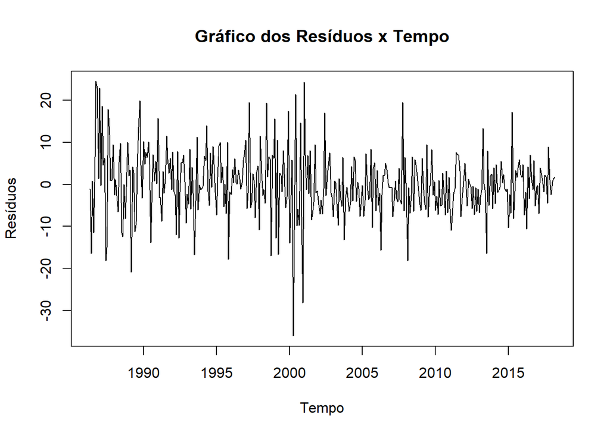

```r
# extrai os resíduos do modelo estimado
residuos <- residuals(modelo_apt)

# Plotar a série temporal dos resíduos
plot(residuos, type = "l",
     main = "Gráfico dos Resíduos x Tempo",
     ylab = "Resíduos",
     xlab = "Tempo")
```

A análise do gráfico dos resíduos, aparentemente, não exibe nenhum padrão típico e aparnete de autocorrelação, positiva ou negativa, nos resíduos.

Para testar formalmente a presença de autocorrelação nos resíduos, o teste de Durbin-Watson pode ser executado usando o função `dwtest()` do pacote `lmtest`:

```r
dwtest(modelo_apt)
```

```
    Durbin-Watson test

data:  modelo_apt
DW = 2.0974, p-value = 0.8176
alternative hypothesis: true autocorrelation is greater than 0
```

Como o valor-p do teste foi de 0,8176, os dados não fornecem evidências para rejeitar a hipótese nula de que os resíduos do modelo não apresentam autocorrelação de primeira ordem nos resíduos, ao nível de 1% de significância.

Um teste alternativo para autocorrelação é o teste de Breusch-Godfrey. Ele é um teste mais geral para autocorrelação do que o teste de Durbin-Watson e nos permite testar autocorrelação de ordem superior.

Ele também é implementado no pacote **lmtest**, na função `bgtest()`. Novamente, sua execução é simples, sendo necessário apenas alterar o argumento `order`, que é 1 por padrão, para permitir a inclusão de mais defasagens. Definindo `order` como 10, temos:

```r
bgtest(modelo_apt, order = 10)
```

```
    Breusch-Godfrey test for serial correlation of order up to 10

data:  modelo_apt
LM test = 4.7666, df = 10, p-value = 0.9062
```

Como o valor-p do teste foi de 0.9062, os dados não fornecem evidências para rejeitar a hipótese nula de que os resíduos do modelo não apresentam autocorrelação de até a décima ordem nos resíduos, ao nível de 1% de significância.

Comparando os resultados da regressão para o modelo no estilo APT, utilizando erros padrão robustos com aqueles que utilizam erros padrão ordinários, observamos que as mudanças na significância são apenas marginais. Naturalmente, apenas os erros padrão foram alterados, e as estimativas dos parâmetros permanecem idênticas às estimadas anteriormente. No entanto, isso não resultou em mudanças nas conclusões sobre a significância, ou não, de qualquer variável.

### 4.2.5 Erros-Padrão Robustos à Heterocedasticidade e à Autocorrelação de Newey-West

Nesta subseção, mostramos como obter os erros padrão robustos à heterocedasticidade e autocorrelação de Newey-West, caso fosse necessário.

Para isso, em vez de utilizar **vcovHC**, usamos a função **NeweyWest**, também fornecida pelo pacote **sandwich**:

```r
coeftest(modelo_apt, vcov = NeweyWest(modelo_apt, lag = 6, adjust = T,
                                        prewhite = F))
```

```
t test of coefficients:

               Estimate Std. Error t value  Pr(>|t|)
(Intercept)   1.3260025  0.5027048  2.6377  0.008694 **
retexc_sp500  1.2807988  0.0998922 12.8218 < 2.2e-16 ***
dprod        -0.3030317  0.5216170 -0.5809  0.561625
dcredit      -0.0253637  0.0223410 -1.1353  0.256975
dinflation    2.1946700  1.3136172  1.6707  0.095614 .
dmoney       -0.0068714  0.0109474 -0.6277  0.530596
dspread       2.2600645  2.8418132  0.7953  0.426948
rterm         4.7330689  1.7585143  2.6915  0.007431 **
---
Signif. codes:  0 '***' 0.001 '**' 0.01 '*' 0.05 '.' 0.1 ' ' 1
```

## 4.3 Modelo com Defasagem Distribuída

```r
# pacote necessario
library(AER) # contém os dados USMacroG

# carrega os dados
data(USMacroG)
```

Considere o seguinte modelo com defasagem distribuída (*distributed-lag model*):

$$\text{Consumo}_{t} = \beta_0 + \beta_1 \text{dpi}_{t} + \beta_2 \text{dpi}_{t-1} + u_t$$
Podemos estimá-lo em R usando a função `dynlm` do pacote `dynlm` fazendo:

```r
# estima o modelo
consumo_dlm <- dynlm(consumption ~ dpi + L(dpi), data = USMacroG)

# resultados
summary(consumo_dlm)
```

```
Time series regression with "ts" data:
Start = 1950(2), End = 2000(4)

Call:
dynlm(formula = consumption ~ dpi + L(dpi), data = USMacroG)

Residuals:
    Min      1Q  Median      3Q     Max
-190.02  -56.68    1.58   49.91  323.94

Coefficients:
             Estimate Std. Error t value Pr(>|t|)
(Intercept) -81.07959   14.50814  -5.589 7.43e-08 ***
dpi           0.89117    0.20625   4.321 2.45e-05 ***
L(dpi)        0.03091    0.20754   0.149    0.882
---
Signif. codes:  0 '***' 0.001 '**' 0.01 '*' 0.05 '.' 0.1 ' ' 1

Residual standard error: 87.58 on 200 degrees of freedom
Multiple R-squared:  0.9964,    Adjusted R-squared:  0.9964
F-statistic: 2.785e+04 on 2 and 200 DF,  p-value: < 2.2e-16
```

## 4.4 Modelo Autorregressivo com Defasagem Distribuída

Considere o seguinte modelo autorregressivo com defasagem distribuída (*autoregressive distributed-lag model*):

$$\text{Consumo}_{t} = \beta_0 + \beta_1 \text{dpi}_{t} + \beta_2 \text{Consumo}_{t-1} + u_t$$
Podemos estimá-lo em R usando a função `dynlm` do pacote `dynlm` fazendo:

```r
# estima o modelo
consumo_adlm <- dynlm(consumption ~ dpi + L(consumption), data = USMacroG)

# resultados
summary(consumo_adlm)
```

```
Time series regression with "ts" data:
Start = 1950(2), End = 2000(4)

Call:
dynlm(formula = consumption ~ dpi + L(consumption), data = USMacroG)

Residuals:
     Min       1Q   Median       3Q      Max
-101.303   -9.674    1.141   12.691   45.322

Coefficients:
                Estimate Std. Error t value Pr(>|t|)
(Intercept)     0.535216   3.845170   0.139    0.889
dpi            -0.004064   0.016626  -0.244    0.807
L(consumption)  1.013111   0.018161  55.785   <2e-16 ***
---
Signif. codes:  0 '***' 0.001 '**' 0.01 '*' 0.05 '.' 0.1 ' ' 1

Residual standard error: 21.52 on 200 degrees of freedom
Multiple R-squared:  0.9998,    Adjusted R-squared:  0.9998
F-statistic: 4.627e+05 on 2 and 200 DF,  p-value: < 2.2e-16
```

## 4.5 Teste de Abrangência (*Encompassing Test*)

Após estimarmos os dois modelos, como podemos decidir qual apresentou o melhor ajuste aos dados? E temos um problema, os modelos não são *nested* (aninhados ou encaixados).

O teste de Abrangência (*Ecompassign test*) transforme a comparação de modelos não aninhados na comparação de modelos aninhados. O procedimento é o seguinte:

1. Ajuste um modelo abrangente que compreende todos os regressores de ambos modelos concorrentes.
2. Compare cada um dos dois modelos não aninhados com o modelo abrangente.
3. Se um modelo não for significativamente pior do que o modelo abrangente enquanto o outro for, este teste favoreceria o primeiro modelo sobre o último.

Podemos executar o teste com a função do pacote lmtest:

```r
encomptest(consumo_dlm, consumo_adlm)
```

```
Encompassing test

Model 1: consumption ~ dpi + L(dpi)
Model 2: consumption ~ dpi + L(consumption)
Model E: consumption ~ dpi + L(dpi) + L(consumption)
          Res.Df Df        F    Pr(>F)
M1 vs. ME    199 -1 3951.448 < 2.2e-16 ***
M2 vs. ME    199 -1   51.661 1.299e-11 ***
---
Signif. codes:  0 '***' 0.001 '**' 0.01 '*' 0.05 '.' 0.1 ' ' 1
```

**Interpretação**: Ambos os modelos apresentam desempenho significativamente pior em comparação com o modelo abrangente, embora a estatística F seja muito menor para o modelo autorregressivo com defasagem distribuída (`consumo_adlm`)

# 5 Referências

BROOKS, C. **[R Guide to Accompany Introductory Econometrics for Finance](https://www.cambridge.org/academic/subjects/economics/finance/r-guide-accompany-introductory-econometrics-finance)**. 4th. ed. [s.l.] Cambridge University Press, 2023.